# COVID-19 Case Study

Sung Cho

Etienne Lee

Leo Li

# 1 Background

The outbreak of the novel Corona virus disease 2019 (COVID-19) was declared a public health emergency of international concern by the World Health Organization (WHO) on January 30, 2020. Upwards of [755 million cases have been confirmed worldwide, with nearly 6.8 million associated deaths](https://covid19.who.int/) by Feb of 2023. Within the US alone, there have been [over 1.1 million deaths and upwards of 102 million cases reported](https://covid.cdc.gov/covid-data-tracker/#trends_dailytrendscases) by Feb of 2023. Governments around the world have implemented and suggested a number of policies to lessen the spread of the pandemic, including mask-wearing requirements, travel restrictions, business and school closures, and even stay-at-home orders. The global pandemic has impacted the lives of individuals in countless ways, and though many countries have begun vaccinating individuals, the long-term impact of the virus remains unclear.

The impact of COVID-19 on a given segment of the population appears to vary drastically based on the socioeconomic characteristics of the segment. In particular, differing rates of infection and fatalities have been reported among different [racial groups](https://www.cdc.gov/coronavirus/2019-ncov/covid-data/investigations-discovery/hospitalization-death-by-race-ethnicity.html), [age groups](https://www.cdc.gov/coronavirus/2019-ncov/covid-data/investigations-discovery/hospitalization-death-by-age.html), and [socioeconomic groups](https://www.ncbi.nlm.nih.gov/pmc/articles/PMC7221360/). One of the most important metrics for determining the impact of the pandemic is the death rate, which is the proportion of people within the total population that die due to the the disease.

We assembled this dataset for our research with the goal of investigating the effectiveness of lockdowns in flattening the COVID curve. We are providing a portion of the cleaned dataset for this case study.

There are two main goals for this case study:

1.We aim to show the dynamic evolution of COVID cases and COVID-related deaths at the state level.

2. We aim to identify county-level demographic and policy interventions that are associated with mortality rates in the US. We will construct models to find possible factors related to county-level COVID-19 mortality rates.
3. This is a rather complex project, but with our team’s help, we have made your job easier.
4. Please hide all unnecessary lengthy R-output and keep your write-up neat and readable.

**Remark 2:** A group of RAs spent tremendous amount of time working together to assemble the data. It requires data wrangling skills.

# 2 Data Summary

The data comes from several different sources:

1. [County-level infection and fatality data](https://github.com/nytimes/covid-19-data) - This dataset gives daily cumulative numbers on infection and fatality for each county.
   - [NYC data](https://github.com/nychealth/coronavirus-data)
2. [County-level socioeconomic data](https://www.ers.usda.gov/data-products/atlas-of-rural-and-small-town-america/download-the-data/) - The following are the four relevant datasets from this site.
   1. Income - Poverty level and household income.
   2. Jobs - Employment type, rate, and change.
   3. People - Population size, density, education level, race, age, household size, and migration rates.
   4. County Classifications - Type of county (rural or urban on a rural-urban continuum scale).
3. [Intervention Policy Data](https://github.com/JieYingWu/COVID-19_US_County-level_Summaries/blob/master/data/interventions.csv) - This dataset is a manually compiled list of the dates that interventions/lockdown policies were implemented and lifted at the county level.

# 3 EDA

In this case study, we use the following three nearly cleaned data:

- **covid_county.csv**: County-level socialeconomic information that combines the above-mentioned 4 datasets: Income (Poverty level and household income), Jobs (Employment type, rate, and change), People (Population size, density, education level, race, age, household size, and migration rates), County Classifications
- **covid_rates.csv**: Daily cumulative numbers on infection and fatality for each county
- **covid_intervention.csv**: County-level lockdown intervention.

Among all data, the unique identifier of county is `FIPS`.

The cleaning procedure is attached in `Appendix 2: Data cleaning` You may go through it if you are interested or would like to make any changes.

**It may need more data wrangling.**

First read in the data.

## 3.1 Understand the data

The detailed description of variables is in `Appendix 1: Data description`. Please get familiar with the variables. Summarize the two data briefly.

```
## [1] 3279  208
```

```
## [1] 1008984       8
```

```
## Rows: 3,279
## Columns: 15
## $ FIPS                 <int> 0, 1000, 1001, 1003, 1005, 1007, 1009, 1011, 1013…
## $ State                <chr> "US", "AL", "AL", "AL", "AL", "AL", "AL", "AL", "…
## $ County               <chr> "United States", "Alabama", "Autauga", "Baldwin",…
## $ MedHHInc             <int> 61937, 49881, 59338, 57588, 34382, 46064, 50412, …
## $ PerCapitaInc         <int> 32621, 26846, 29372, 31203, 18461, 20199, 22656, …
## $ PovertyUnder18Pct    <dbl> 18.0, 23.9, 19.3, 13.9, 43.9, 27.8, 18.0, 68.3, 3…
## $ PovertyAllAgesPct    <dbl> 13.1, 16.8, 13.8, 9.8, 30.9, 21.8, 13.2, 42.5, 24…
## $ Deep_Pov_All         <dbl> 6.25, 7.61, 6.14, 4.48, 12.75, 5.90, 7.31, 17.66,…
## $ Deep_Pov_Children    <dbl> 8.60, 11.59, 8.91, 6.21, 26.71, 9.26, 12.33, 44.6…
## $ PovertyUnder18Num    <int> 12997532, 255613, 2509, 6442, 2242, 1238, 2374, 1…
## $ PovertyAllAgesNum    <int> 41852315, 801758, 7587, 21069, 6788, 4400, 7527, …
## $ PopChangeRate1819    <dbl> 0.475, 0.317, 0.605, 2.469, -0.748, 0.121, 0.095,…
## $ PopChangeRate1019    <dbl> 6.116, 2.461, 2.001, 21.911, -9.664, -2.081, 0.78…
## $ TotalPopEst2019      <int> 328239523, 4903185, 55869, 223234, 24686, 22394, …
## $ NetMigrationRate1019 <dbl> 2.485, 1.059, 0.686, 21.001, -8.797, -2.099, -0.0…
```

```
## Rows: 1,008,984
## Columns: 8
## $ FIPS            <int> 10001, 10001, 10001, 10001, 10001, 10001, 10001, 10001…
## $ date            <IDate> 2020-03-18, 2020-03-19, 2020-03-20, 2020-03-21, 2020…
## $ County          <chr> "Kent", "Kent", "Kent", "Kent", "Kent", "Kent", "Kent"…
## $ State           <chr> "Delaware", "Delaware", "Delaware", "Delaware", "Delaw…
## $ cum_cases       <int> 3, 4, 4, 5, 5, 9, 10, 14, 19, 21, 25, 25, 27, 34, 41, …
## $ cum_deaths      <int> 0, 0, 0, 0, 0, 0, 0, 0, 0, 0, 2, 2, 2, 2, 2, 2, 2, 2, …
## $ week            <int> 9, 9, 9, 9, 10, 10, 10, 10, 10, 10, 10, 11, 11, 11, 11…
## $ TotalPopEst2019 <int> 180786, 180786, 180786, 180786, 180786, 180786, 180786…
```

```
##   n_counties n_states n_vars
## 1       3279       53    208
```

```
##    n_rows n_counties n_states   min_date   max_date
## 1 1008984       3108       49 2020-01-21 2021-02-20
```

```
## # A tibble: 15 × 2
##    variable                   n_missing
##    <chr>                          <int>
##  1 HiAmenity                        172
##  2 Gas_Change                       170
##  3 Oil_Change                       170
##  4 Oil_Gas_Change                   170
##  5 HiCreativeClass2000              140
##  6 EconomicDependence2000           138
##  7 FarmDependent2003                138
##  8 ManufacturingDependent2000       138
##  9 LowEducation2000                 138
## 10 RetirementDestination2000        138
## 11 PersistentPoverty2000            138
## 12 PersistentChildPoverty2004       138
## 13 RecreationDependent2000          138
## 14 Type_2015_Update                 136
## 15 Type_2015_Farming_NO             136
```

```
## # A tibble: 8 × 2
##   variable        n_missing
##   <chr>               <int>
## 1 FIPS                    0
## 2 date                    0
## 3 County                  0
## 4 State                   0
## 5 cum_cases               0
## 6 cum_deaths              0
## 7 week                    0
## 8 TotalPopEst2019         0
```

## 3.2 COVID case trend

It is crucial to decide the right granularity for visualization and analysis. We will compare daily vs weekly total new cases by state and we will see it is hard to interpret daily report.

1. Plot **new** COVID cases in NY, WA and FL by state and by day. Any irregular pattern? What is the biggest problem of using single day data?

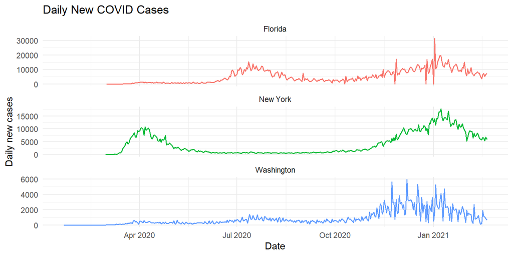

Answer: The daily new case plots for New York, Washington, and Florida show a lot of short-term volatility rather than smooth, consistent trends. There are frequent spikes and dips from one day to the next, many of which don’t seem to reflect actual changes in disease spread. Instead, the patterns suggest irregular reporting, where low counts on certain days are followed by sudden jumps. The main problem with relying on single-day data is that it is noisy and highly sensitive to reporting practices. Factors like weekend reporting delays, testing backlogs, and administrative batching can distort the data, making it hard to interpret real trends. Because of this, daily figures can be misleading, and it is generally more reliable to look at smoothed measures like 7-day averages to understand the underlying trajectory.

2. Create **weekly new** cases per 100k `weekly_case_per100k`. Plot the spaghetti plots of `weekly_case_per100k` by state. Use `TotalPopEst2019` as population.

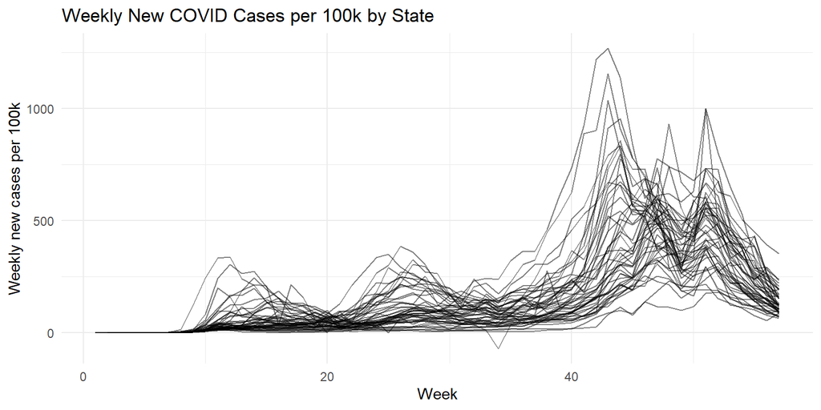

3. Summarize the COVID case trend among states based on the plot in ii). What could be the possible reasons to explain the variabilities?

```
## # A tibble: 10 × 3
##    State        peak_weekly_case_per100k avg_weekly_case_per100k
##    <chr>                           <dbl>                   <dbl>
##  1 North Dakota                    1269.                    261.
##  2 South Dakota                    1153.                    253.
##  3 Iowa                            1036.                    210.
##  4 Arizona                          999.                    198.
##  5 New Jersey                       997.                    169.
##  6 Wyoming                          955.                    186.
##  7 Tennessee                        930.                    213.
##  8 Nebraska                         857.                    195.
##  9 Wisconsin                        835.                    191.
## 10 Minnesota                        831.                    166.
```

Answer: The plot shows that COVID case trends across states follow a broadly similar pattern—an initial surge in the spring, a relative slowdown in the summer for many states, and then a much larger, more widespread spike in the fall and winter. However, there is substantial variation in both the timing and magnitude of these waves. For example, states like New York experienced a sharp early peak, while others, particularly in the Midwest and South, saw their largest surges later in the year. These differences can be explained by several factors. Population density and urbanization likely played a major role early on, with dense states seeing faster initial spread. Policy responses—such as lockdown timing, mask mandates, and reopening strategies—also varied across states and influenced transmission dynamics. Additionally, behavioral differences, mobility patterns, and even seasonal factors (like people moving indoors in colder months) likely contributed to the variation in case trajectories.

## 3.3 COVID death trend

In this section, you will use the modern spatial workflow in R (`sf` + `ggplot2`) to visualize COVID outcomes.

**Important:** Do **not** use `usmap` for this part. The goal is to become comfortable working directly with `sf` objects and `geom_sf()`.

By doing so, you will:

- Become comfortable working with `sf` objects.
- Practice spatial joins between geometry and tabular data.
- Use `geom_sf()` within the `ggplot2` grammar.
- Understand how geographic resolution affects interpretation.

### 3.3.1 State-Level Choropleths (2020)

Using `sf` state geometries:

- Obtain U.S. state boundaries as an `sf` object.
- Join your state-level monthly COVID data to the spatial object.
- Create **one faceted choropleth** showing monthly deaths per 100k for each month of 2020.
- Use a **fixed color scale across months** so visual comparisons are meaningful.
- Exclude Alaska and Hawaii if desired.

**Hints:**

- Use `geom_sf()` for mapping.
- Use `facet_wrap(~month)` for the 12 panels.
- Set `limits =` inside `scale_fill_gradient()` (or similar) to fix the scale.
- Extract month/year using `lubridate::month()` and `lubridate::year()`.

**Deliverable:** One faceted state-level choropleth figure.

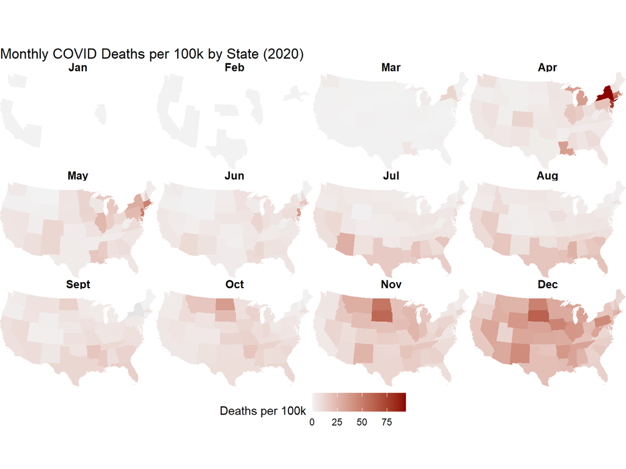

### 3.3.2 County-Level Choropleth

Now extend the analysis to a finer geographic resolution.

- Obtain county boundaries as an `sf` object.
- Join county-level COVID outcomes (e.g., cumulative 2020 deaths per 100k).
- Produce a county-level choropleth using `geom_sf()`.

Keep the map visually clean (e.g., suppress county borders if cluttered).

If you compute any distances or spatial quantities, project to a CRS in meters.

**Deliverable:** One county-level choropleth.

[figure not shown]

### 3.3.3 Brief Interpretation (Conceptual)

In **3–5 sentences**, briefly discuss:

- What spatial patterns do you observe?
- Do you see regional clustering?
- How does the county map differ from the state map in terms of information revealed?

Answer: There are clear spatial patterns and regional clustering in COVID deaths. Early in the year, higher death rates are concentrated in the Northeast (especially New York and surrounding states), while later months show stronger intensity shifting toward the Midwest and parts of the South. This suggests the pandemic moved in waves across regions rather than affecting all areas uniformly at the same time. Yes, there is evident regional clustering: neighboring states tend to exhibit similar intensity levels, especially during peak periods (e.g., Midwest cluster in fall/winter). This reflects geographic spread and shared regional dynamics such as mobility and policy environments. The county-level map reveals much more granular heterogeneity compared to the state map. While the state map smooths variation and can mask within-state differences, the county map shows localized hotspots and sharp disparities (e.g., specific counties with extremely high death rates within otherwise moderate states). This highlights that aggregation at the state level can obscure important local patterns.

# 4 COVID factor

We now try to build a good parsimonious model to find possible factors related to death rate on county level. Let us not take time series into account for the moment and use the total number as of *March 1, 2021*.

1. Create the response variable `total_death_per100k` as the total of number of COVID deaths per 100k by *March 1, 2021*. We suggest to take log transformation as `log_total_death_per100k = log(total_death_per100k + 1)`. Merge `total_death_per100k` to `county_data` for the following analysis.
2. Select possible variables in `county_data` as covariates. We provide `county_data_sub`, a subset variables from `county_data`, for you to get started. Please add any potential variables as you wish.
   1. Report missing values in your final subset of variables.
   2. In the following anaylsis, you may ignore the missing values.

```
## # A tibble: 39 × 2
##    variable                                   n_missing
##    <chr>                                          <int>
##  1 HiAmenity                                        172
##  2 HiCreativeClass2000                              140
##  3 Type_2015_Update                                 136
##  4 Perpov_1980_0711                                 136
##  5 Retirement_Destination_2015_Update               136
##  6 PovertyAllAgesPct                                 86
##  7 ForeignBornPct                                    85
##  8 Net_International_Migration_Rate_2010_2019        85
##  9 NetMigrationRate1019                              85
## 10 NaturalChangeRate1019                             85
## # ℹ 29 more rows
```

A number of variables contain missing values, though none are critically sparse, the most affected variable (HiAmenity) is missing only 172 out of 3,279 counties. After removing all rows with any missing values, we retain 3,105 counties for the following analysis.

3. Use LASSO to choose a parsimonious model with all available sensible county-level information. **Force in State** in the process. Why we need to force in State? You may use `lambda.1se` to choose a smaller model.

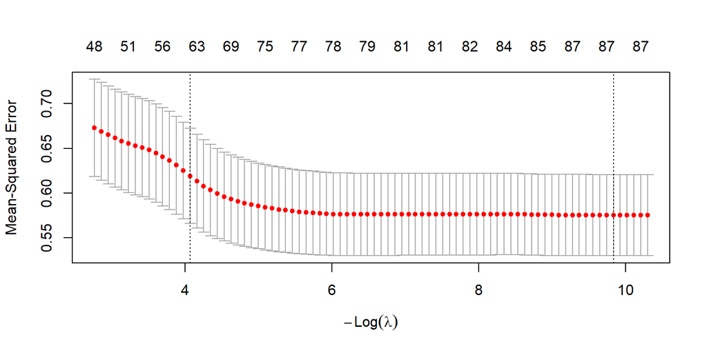

State is forced into the model to control for state-level confounders such as differing policy responses, healthcare infrastructure, and reporting practices. Without controlling for State, these effects would be absorbed into the county-level coefficients and bias our estimates. We select lambda.1se which yields a simpler model with ~63 non-zero coefficients while not sacrificing much predictive performance compared to lambda.min.

4. Use a quick backward elimination to fine tune the LASSO model from iii). Again **force in State** in the process.
5. If necessary, reduce the model from iv) to a final model with all variables being significant at 0.05 level. Are the linear model assumptions all reasonably met?

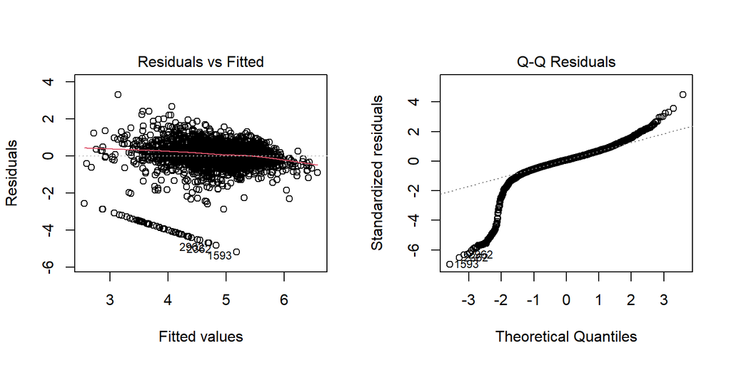

6. It has been shown that COVID affects elderly the most. It is also claimed that the COVID death rate among African Americans and Latinos is higher. Does your analysis support these arguments?

```
##                      Estimate Std. Error t value Pr(>|t|)
## Age65AndOlderPct2010  0.03559    0.00720    4.94 8.11e-07
## HispanicPct2010       0.00761    0.00199    3.83 1.31e-04
```

Our analysis partially supports these claims. The coefficient for Age65AndOlderPct2010 is positive and highly significant (0.036, p < 0.001), corresponding to a 3.6% increase in county death rate per additional percentage point of elderly population, strongly supporting the claim that COVID disproportionately affects the elderly. HispanicPct2010 is also positive and significant (0.008, p < 0.001), supporting the claim for Latino communities, potentially reflecting higher exposure risk due to essential worker roles and larger household sizes. However, BlackNonHispanicPct2010 was zeroed out by LASSO, suggesting that after controlling for state effects and socioeconomic factors such as income and poverty, Black population percentage does not add additional explanatory power, implying the disparity may be driven more by socioeconomic conditions than race itself.

7. Based on your final model, summarize your findings. In particular, summarize the state effect controlling for others. Provide intervention recommendations to policy makers to reduce COVID death rate.

```
##                          Estimate Std. Error t value Pr(>|t|)
## PerCapitaInc            -1.59e-05   2.97e-06   -5.36 9.18e-08
## PctEmpConstruction      -3.65e-02   6.42e-03   -5.69 1.42e-08
## PctEmpAgriculture       -3.51e-02   3.22e-03  -10.90 3.79e-27
## PctEmpManufacturing      7.60e-03   2.76e-03    2.75 5.95e-03
## Age65AndOlderPct2010     3.56e-02   7.20e-03    4.94 8.11e-07
## Under18Pct2010           6.05e-02   6.96e-03    8.69 5.70e-18
## Ed3SomeCollegePct       -1.84e-02   4.93e-03   -3.73 1.93e-04
## NetMigrationRate1019    -1.20e-02   2.38e-03   -5.04 4.81e-07
## NaturalChangeRate1019   -5.00e-02   9.14e-03   -5.47 4.83e-08
## WhiteNonHispanicPct2010 -4.45e-03   1.35e-03   -3.30 9.91e-04
## HispanicPct2010          7.61e-03   1.99e-03    3.83 1.31e-04
## Type_2015_Update        -2.60e-02   8.10e-03   -3.21 1.34e-03
```

```
##         Estimate Std. Error t value Pr(>|t|)
## StateVT   -2.007      0.226   -8.88 1.10e-18
## StateME   -1.516      0.213   -7.11 1.44e-12
## StateUT   -1.239      0.184   -6.73 2.08e-11
## StateOR   -0.982      0.165   -5.96 2.78e-09
## StateWA   -0.967      0.160   -6.06 1.54e-09
```

```
##         Estimate Std. Error t value Pr(>|t|)
## StateNJ    0.272      0.197   1.381 1.67e-01
## StateMT    0.381      0.149   2.549 1.09e-02
## StateSD    0.630      0.143   4.412 1.06e-05
## StateDC    0.668      0.764   0.874 3.82e-01
## StateND    0.743      0.155   4.784 1.80e-06
```

Our final model explains 37% of the variance in county-level COVID death rates (adjusted R² = 0.36). Among the most significant county-level predictors, higher agricultural employment (PctEmpAgriculture) and faster natural population growth (NaturalChangeRate1019) were strongly associated with lower death rates, likely reflecting younger and healthier rural populations. Conversely, higher proportions of elderly residents (Age65AndOlderPct2010) were associated with higher death rates, consistent with the well-known vulnerability of older populations to COVID-19. The positive effect of youth population (Under18Pct2010) is more surprising, and may reflect that counties with more children tend to have larger household sizes, facilitating spread to vulnerable adults.

Controlling for these county-level factors, there remain significant state-level differences in death rates. States with the lowest death rates relative to Alabama include Vermont, Maine, Utah, Oregon, and Washington, predominantly New England and Pacific Northwest states known for early and strict public health interventions. In contrast, North Dakota and South Dakota had significantly higher death rates, consistent with their well-documented resistance to lockdown measures early in the pandemic.

Based on these findings, we recommend that policymakers prioritize early implementation of lockdowns and mask mandates, particularly in states with resistance to such measures. Additional targeted interventions should focus on counties with high elderly populations and low income levels, as these appear to be the most vulnerable.

8. What else can we do to improve our model? What other important information we may have missed?

Several improvements could be made to this model. First, counties with zero reported deaths may reflect unreported cases rather than true zeros, distorting the model as seen in the residual plot — these could be handled by dropping them entirely or using a more appropriate transformation. Second, rather than dropping the 174 counties with missing values via na.omit(), imputing missing values via softImpute as suggested in part ix) could recover useful data and improve model stability.

More importantly, several key variables likely explaining much of the remaining 63% unexplained variance are absent from our data. Vaccination rates, hospital capacity and healthcare access, mask mandate compliance, mobility patterns, and county-level comorbidity rates such as obesity and diabetes are all strongly linked to COVID severity but were unavailable at the county level at the time of data collection. Including these variables would likely substantially improve the model’s explanatory power.

9. (Optional) Would your findings be very different if you had refined the data in some way or imputed the missing values in part ii). Check PCA lecture, section 10 for imputations via `softImpute`.

# 5 Executive summary

Please summarize this project as follows (no more than one page):

- Goal of the study
- Data
  - Source and a brief description of the data
  - How do you assemble them together (mostly done by our team but you may present them as if you have done so)
- Analyses
- Methods used
- Findings
- Limitations

**Goal**

This study has two main goals: to visualize the dynamic evolution of COVID-19 cases and deaths at the state level over time, and to identify county-level demographic and socioeconomic factors associated with COVID-19 mortality rates across the United States.

**Data**

Data was assembled from three sources:

- **NYT GitHub Repository**: County-level daily COVID-19 infection and fatality counts
- **USDA Economic Research Service**: County-level socioeconomic data covering income, employment, education, population, and county classifications
- **Intervention Policy Data**: County-level lockdown and intervention dates

Assembling these datasets required substantial data wrangling, NYC borough-level data was extracted and reformatted separately, all datasets were merged using FIPS codes as the unique county identifier, cumulative death and case counts were computed from raw daily figures, and population estimates were joined to enable per-100k normalization.

**Analyses**

- **EDA**: Spaghetti plots of weekly cases per 100k and choropleth maps of monthly deaths per 100k at both state and county level, built using the `sf` and `ggplot2` spatial workflow
- **Modeling**: LASSO regression with 10-fold cross-validation to select county-level predictors of log COVID death rate per 100k as of March 1, 2021, with State forced in as a control variable, followed by backward elimination via `stepAIC` and removal of remaining insignificant variables at the 0.05 level

**Findings**

COVID cases followed broadly similar wave patterns across states, with an early surge in the Northeast, a relative slowdown in summer, and a much larger wave in fall and winter. State and county choropleth maps confirmed regional clustering, with deaths concentrated in the Northeast early and shifting toward the Midwest and South later in the year.

At the county level, our final model (adjusted R² = 0.36) identified the following key factors:

- **Increases death rate**: Higher elderly population, higher youth population, higher Hispanic population, higher manufacturing employment
- **Decreases death rate**: Higher income, agricultural employment, education levels, natural population growth

Controlling for county-level factors, states in New England and the Pacific Northwest such as Vermont, Maine, Oregon and Washington had significantly lower death rates, consistent with their early and strict public health interventions, while Great Plains states such as North Dakota and South Dakota had significantly higher death rates, consistent with their resistance to lockdown measures. We therefore recommend that policymakers prioritize early lockdowns and mask mandates, with targeted support for counties with high elderly populations and low income levels.

**Limitations**

# 6 Potential final projects

## 6.1 Does the govenment lockdown policy work in reducing covid death rates?

You may use the available data together with `covid_intervention` as well as more potential data not included here.

## 6.2 Do vaccinations help reducing death rates from `COVID`?

# 7 Appendix 1: Data description

A detailed summary of the variables in each data set follows:

## 7.1 Infection and fatality data

- date: Date
- county: County name
- state: State name
- fips: County code that uniquely identifies a county
- cases: Number of cumulative COVID-19 infections
- deaths: Number of cumulative COVID-19 deaths

## 7.2 Socioeconomic demographics

*Income*: Poverty level and household income

- PovertyUnder18Pct: Poverty rate for children age 0-17, 2018
- Deep_Pov_All: Deep poverty, 2014-18
- Deep_Pov_Children: Deep poverty for children, 2014-18
- PovertyAllAgesPct: Poverty rate, 2018
- MedHHInc: Median household income, 2018 (In 2018 dollars)
- PerCapitaInc: Per capita income in the past 12 months (In 2018 inflation adjusted dollars), 2014-18
- PovertyAllAgesNum: Number of people of all ages in poverty, 2018
- PovertyUnder18Num: Number of people age 0-17 in poverty, 2018

*Jobs*: Employment type, rate, and change

- UnempRate2007-2019: Unemployment rate, 2007-2019
- NumEmployed2007-2019: Employed, 2007-2019
- NumUnemployed2007-2019: Unemployed, 2007-2019
- PctEmpChange1019: Percent employment change, 2010-19
- PctEmpChange1819: Percent employment change, 2018-19
- PctEmpChange0719: Percent employment change, 2007-19
- PctEmpChange0710: Percent employment change, 2007-10
- NumCivEmployed: Civilian employed population 16 years and over, 2014-18
- NumCivLaborforce2007-2019: Civilian labor force, 2007-2019
- PctEmpFIRE: Percent of the civilian labor force 16 and over employed in finance and insurance, and real estate and rental and leasing, 2014-18
- PctEmpConstruction: Percent of the civilian labor force 16 and over employed in construction, 2014-18
- PctEmpTrans: Percent of the civilian labor force 16 and over employed in transportation, warehousing and utilities, 2014-18
- PctEmpMining: Percent of the civilian labor force 16 and over employed in mining, quarrying, oil and gas extraction, 2014-18
- PctEmpTrade: Percent of the civilian labor force 16 and over employed in wholesale and retail trade, 2014-18
- PctEmpInformation: Percent of the civilian labor force 16 and over employed in information services, 2014-18
- PctEmpAgriculture: Percent of the civilian labor force 16 and over employed in agriculture, forestry, fishing, and hunting, 2014-18
- PctEmpManufacturing: Percent of the civilian labor force 16 and over employed in manufacturing, 2014-18
- PctEmpServices: Percent of the civilian labor force 16 and over employed in services, 2014-18
- PctEmpGovt: Percent of the civilian labor force 16 and over employed in public administration, 2014-18

*People*: Population size, density, education level, race, age, household size, and migration rates

- PopDensity2010: Population density, 2010
- LandAreaSQMiles2010: Land area in square miles, 2010
- TotalHH: Total number of households, 2014-18
- TotalOccHU: Total number of occupied housing units, 2014-18
- AvgHHSize: Average household size, 2014-18
- OwnHomeNum: Number of owner occupied housing units, 2014-18
- OwnHomePct: Percent of owner occupied housing units, 2014-18
- NonEnglishHHPct: Percent of non-English speaking households of total households, 2014-18
- HH65PlusAlonePct: Percent of persons 65 or older living alone, 2014-18
- FemaleHHPct: Percent of female headed family households of total households, 2014-18
- FemaleHHNum: Number of female headed family households, 2014-18
- NonEnglishHHNum: Number of non-English speaking households, 2014-18
- HH65PlusAloneNum: Number of persons 65 years or older living alone, 2014-18
- Age65AndOlderPct2010: Percent of population 65 or older, 2010
- Age65AndOlderNum2010: Population 65 years or older, 2010
- TotalPop25Plus: Total population 25 and older, 2014-18 - 5-year average
- Under18Pct2010: Percent of population under age 18, 2010
- Under18Num2010: Population under age 18, 2010
- Ed1LessThanHSPct: Percent of persons with no high school diploma or GED, adults 25 and over, 2014-18
- Ed2HSDiplomaOnlyPct: Percent of persons with a high school diploma or GED only, adults 25 and over, 2014-18
- Ed3SomeCollegePct: Percent of persons with some college experience, adults 25 and over, 2014-18
- Ed4AssocDegreePct: Percent of persons with an associate’s degree, adults 25 and over, 2014-18
- Ed5CollegePlusPct: Percent of persons with a 4-year college degree or more, adults 25 and over, 2014-18
- Ed1LessThanHSNum: No high school, adults 25 and over, 2014-18
- Ed2HSDiplomaOnlyNum: High school only, adults 25 and over, 2014-18
- Ed3SomeCollegeNum: Some college experience, adults 25 and over, 2014-18
- Ed4AssocDegreeNum: Number of persons with an associate’s degree, adults 25 and over, 2014-18
- Ed5CollegePlusNum: College degree 4-years or more, adults 25 and over, 2014-18
- ForeignBornPct: Percent of total population foreign born, 2014-18
- ForeignBornEuropePct: Percent of persons born in Europe, 2014-18
- ForeignBornMexPct: Percent of persons born in Mexico, 2014-18
- ForeignBornCentralSouthAmPct: Percent of persons born in Central or South America, 2014-18
- ForeignBornAsiaPct: Percent of persons born in Asia, 2014-18
- ForeignBornCaribPct: Percent of persons born in the Caribbean, 2014-18
- ForeignBornAfricaPct: Percent of persons born in Africa, 2014-18
- ForeignBornNum: Number of people foreign born, 2014-18
- ForeignBornCentralSouthAmNum: Number of persons born in Central or South America, 2014-18
- ForeignBornEuropeNum: Number of persons born in Europe, 2014-18
- ForeignBornMexNum: Number of persons born in Mexico, 2014-18
- ForeignBornAfricaNum: Number of persons born in Africa, 2014-18
- ForeignBornAsiaNum: Number of persons born in Asia, 2014-18
- ForeignBornCaribNum: Number of persons born in the Caribbean, 2014-18
- Net_International_Migration_Rate_2010_2019: Net international migration rate, 2010-19
- Net_International_Migration_2010_2019: Net international migration, 2010-19
- Net_International_Migration_2000_2010: Net international migration, 2000-10
- Immigration_Rate_2000_2010: Net international migration rate, 2000-10
- NetMigrationRate0010: Net migration rate, 2000-10
- NetMigrationRate1019: Net migration rate, 2010-19
- NetMigrationNum0010: Net migration, 2000-10
- NetMigration1019: Net Migration, 2010-19
- NaturalChangeRate1019: Natural population change rate, 2010-19
- NaturalChangeRate0010: Natural population change rate, 2000-10
- NaturalChangeNum0010: Natural change, 2000-10
- NaturalChange1019: Natural population change, 2010-19
- TotalPop2010: Population size 4/1/2010 Census
- TotalPopEst2010: Population size 7/1/2010
- TotalPopEst2011: Population size 7/1/2011
- TotalPopEst2012: Population size 7/1/2012
- TotalPopEst2013: Population size 7/1/2013
- TotalPopEst2014: Population size 7/1/2014
- TotalPopEst2015: Population size 7/1/2015
- TotalPopEst2016: Population size 7/1/2016
- TotalPopEst2017: Population size 7/1/2017
- TotalPopEst2018: Population size 7/1/2018
- TotalPopEst2019: Population size 7/1/2019
- TotalPopACS: Total population, 2014-18 - 5-year average
- TotalPopEstBase2010: County Population estimate base 4/1/2010
- NonHispanicAsianPopChangeRate0010: Population change rate Non-Hispanic Asian, 2000-10
- PopChangeRate1819: Population change rate, 2018-19
- PopChangeRate1019: Population change rate, 2010-19
- PopChangeRate0010: Population change rate, 2000-10
- NonHispanicNativeAmericanPopChangeRate0010: Population change rate Non-Hispanic Native American, 2000-10
- HispanicPopChangeRate0010: Population change rate Hispanic, 2000-10
- MultipleRacePopChangeRate0010: Population change rate multiple race, 2000-10
- NonHispanicWhitePopChangeRate0010: Population change rate Non-Hispanic White, 2000-10
- NonHispanicBlackPopChangeRate0010: Population change rate Non-Hispanic African American, 2000-10
- MultipleRacePct2010: Percent multiple race, 2010
- WhiteNonHispanicPct2010: Percent Non-Hispanic White, 2010
- NativeAmericanNonHispanicPct2010: Percent Non-Hispanic Native American, 2010
- BlackNonHispanicPct2010: Percent Non-Hispanic African American, 2010
- AsianNonHispanicPct2010: Percent Non-Hispanic Asian, 2010
- HispanicPct2010: Percent Hispanic, 2010
- MultipleRaceNum2010: Population size multiple race, 2010
- WhiteNonHispanicNum2010: Population size Non-Hispanic White, 2010
- BlackNonHispanicNum2010: Population size Non-Hispanic African American, 2010
- NativeAmericanNonHispanicNum2010: Population size Non-Hispanic Native American, 2010
- AsianNonHispanicNum2010: Population size Non-Hispanic Asian, 2010
- HispanicNum2010: Population size Hispanic, 2010

##County classifications

Type of county (rural or urban on a rural-urban continuum scale)

- Type_2015_Recreation_NO: Recreation counties, 2015 edition
- Type_2015_Farming_NO: Farming-dependent counties, 2015 edition
- Type_2015_Mining_NO: Mining-dependent counties, 2015 edition
- Type_2015_Government_NO: Federal/State government-dependent counties, 2015 edition
- Type_2015_Update: County typology economic types, 2015 edition
- Type_2015_Manufacturing_NO: Manufacturing-dependent counties, 2015 edition
- Type_2015_Nonspecialized_NO: Nonspecialized counties, 2015 edition
- RecreationDependent2000: Nonmetro recreation-dependent, 1997-00
- ManufacturingDependent2000: Manufacturing-dependent, 1998-00
- FarmDependent2003: Farm-dependent, 1998-00
- EconomicDependence2000: Economic dependence, 1998-00
- RuralUrbanContinuumCode2003: Rural-urban continuum code, 2003
- UrbanInfluenceCode2003: Urban influence code, 2003
- RuralUrbanContinuumCode2013: Rural-urban continuum code, 2013
- UrbanInfluenceCode2013: Urban influence code, 2013
- Noncore2013: Nonmetro noncore, outside Micropolitan and Metropolitan, 2013
- Micropolitan2013: Micropolitan, 2013
- Nonmetro2013: Nonmetro, 2013
- Metro2013: Metro, 2013
- Metro_Adjacent2013: Nonmetro, adjacent to metro area, 2013
- Noncore2003: Nonmetro noncore, outside Micropolitan and Metropolitan, 2003
- Micropolitan2003: Micropolitan, 2003
- Metro2003: Metro, 2003
- Nonmetro2003: Nonmetro, 2003
- NonmetroNotAdj2003: Nonmetro, nonadjacent to metro area, 2003
- NonmetroAdj2003: Nonmetro, adjacent to metro area, 2003
- Oil_Gas_Change: Change in the value of onshore oil and natural gas production, 2000-11
- Gas_Change: Change in the value of onshore natural gas production, 2000-11
- Oil_Change: Change in the value of onshore oil production, 2000-11
- Hipov: High poverty counties, 2014-18
- Perpov_1980_0711: Persistent poverty counties, 2015 edition
- PersistentChildPoverty_1980_2011: Persistent child poverty counties, 2015 edition
- PersistentChildPoverty2004: Persistent child poverty counties, 2004
- PersistentPoverty2000: Persistent poverty counties, 2004
- Low_Education_2015_update: Low education counties, 2015 edition
- LowEducation2000: Low education, 2000
- HiCreativeClass2000: Creative class, 2000
- HiAmenity: High natural amenities
- RetirementDestination2000: Retirement destination, 1990-00
- Low_Employment_2015_update: Low employment counties, 2015 edition
- Population_loss_2015_update: Population loss counties, 2015 edition
- Retirement_Destination_2015_Update: Retirement destination counties, 2015 edition

# 8 Appendix 2: Data cleaning

The raw data sets are dirty and need transforming before we can do our EDA. It takes time and efforts to clean and merge different data sources so we provide the final output of the cleaned and merged data. The cleaning procedure is as follows. Please read through to understand what is in the cleaned data. We set `eval = data_cleaned` in the following cleaning chunks so that these cleaning chunks will only run if any of `data/covid_county.csv`, `data/covid_rates.csv` or `data/covid_intervention.csv` does not exist.

We first read in the table using `data.table::fread()`, as we did last time.

## 8.1 Clean NYC data

The original NYC data contains more information than we need. We extract only the number of cases and deaths and format it the same as the `covid_rates` data.

## 8.2 Continental US cases

We only consider cases and death in continental US. Alaska, Hawaii, and Puerto Rico have 02, 15, and 72 as their respective first 2 digits of their FIPS. We use the `%/%` operator for integer division to get the first 2 digits of FIPS. We also remove Virgin Islands and Northern Mariana Islands. All data of counties in NYC are aggregated as `County == "New York City"` in `covid_rates` with no FIPS, so we combine the NYC data into `covid_rate`.

## 8.3 COVID date to week

We set the week of Jan 21, 2020 (the first case of COVID case in US) as the first week (2020-01-19 to 2020-01-25).

## 8.4 COVID infection/mortality rates

Merge the `TotalPopEst2019` variable from the demographic data with `covid_rates` by FIPS.

## 8.5 NA in COVID data

NA values in the `covid_rates` data set correspond to a county not having confirmed cases/deaths. We replace the NA values in these columns with zeros. FIPS for Kansas city, Missouri, Rhode Island and some others are missing. We drop them for the moment and output the data up to week 57 as `covid_rates.csv`.

## 8.6 Formatting date in `int_dates`

We convert the columns representing dates in `int_dates` to R Date types using `as.Date()`. We will need to specify that the `origin` parameter is `"0001-01-01"`. We output the data as `covid_intervention.csv`.

## 8.7 Merge demographic data

Merge the demographic data sets by FIPS and output as `covid_county.csv`.